# Visulisation Project

Dharmi Malde

2023-09-27

# Introduction

{In the fast-moving world of retail, where what people like to buy can change from season to season, it’s really important for stores to understand patterns, figure out insights, and use data to make smart decisions.

# Data Discriptiobn

{Here we have sales for the thousands of product families sold at Favorita stores located in Ecuador. The main meta data includes dates, store and product information, whether that item was being promoted, as well as the sales numbers. Additional files include supplementary information that may effects sales.

store_nbr identifies the store at which the products are sold.

family identifies the type of product sold.

sales gives the total sales for a product family at a particular store at a given date. Fractional values are possible since products can be sold in fractional units (1.5 kg of cheese, for instance, as opposed to 1 bag of chips).

onpromotion gives the total number of items in a product family that were being promoted at a store at a given date.

Store metadata, including city, state, type, and cluster. cluster is a grouping of similar stores.

Ecuador is an oil-dependent country and it’s economical health is highly vulnerable to shocks in oil prices. So we also have daily oil price data.

In addition we also have holidays data and daily transaction data of each store.}

# Exploratory Data Analysis

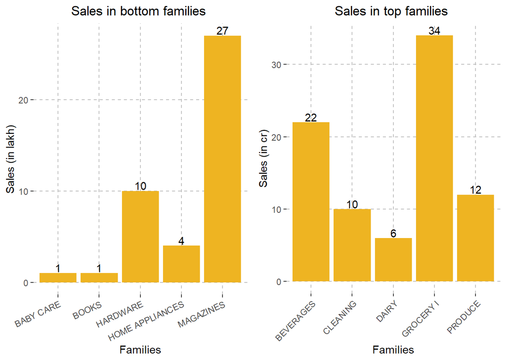

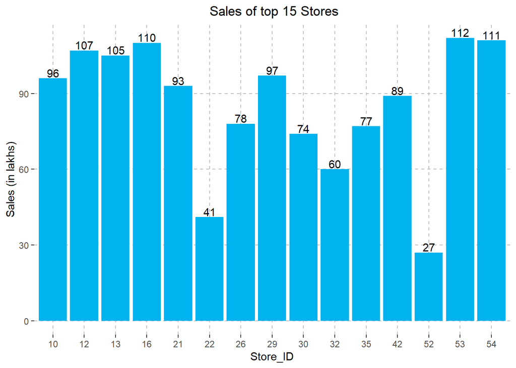

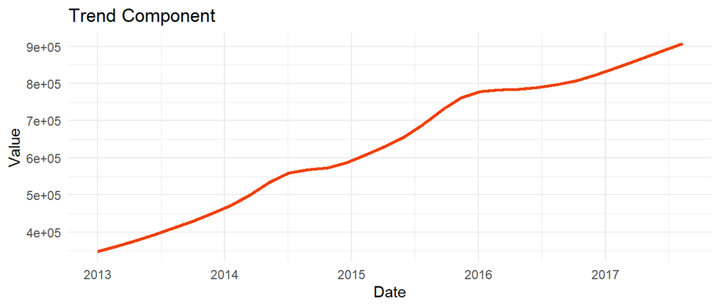

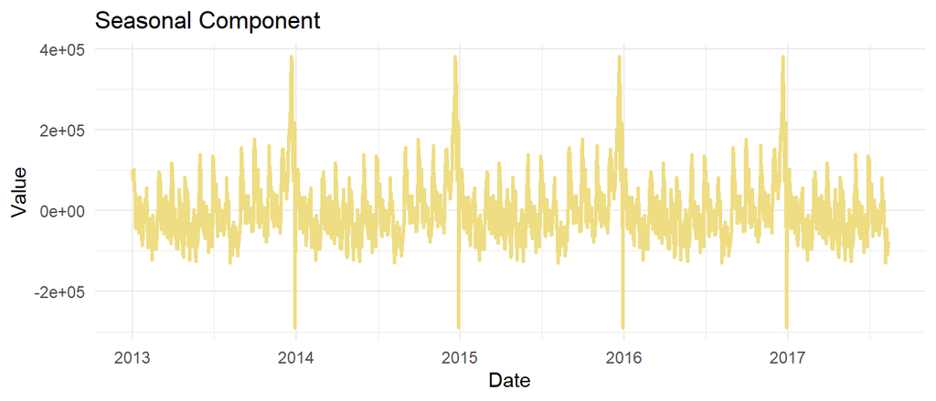

# Conclusion

[output not shown]